# ThinkDSP

This notebook contains solutions to exercises in Chapter 9: Differentiation and Integration

Copyright 2015 Allen Downey

License: [Creative Commons Attribution 4.0 International](http://creativecommons.org/licenses/by/4.0/)

```python
%matplotlib inline

import thinkdsp
import thinkplot
import thinkstats2

import numpy as np
import pandas as pd
import scipy.signal

# suppress division by zero warning
from warnings import simplefilter
simplefilter('ignore', RuntimeWarning)

PI2 = 2 * np.pi
GRAY = '0.7'
```

**Exercise:** The goal of this exercise is to explore the effect of `diff` and `differentiate` on a signal. Create a triangle wave and plot it. Apply the `diff` operator and plot the result. Compute the spectrum of the triangle wave, apply `differentiate`, and plot the result. Convert the spectrum back to a wave and plot it. Are there differences between the effect of `diff` and `differentiate` for this wave?

*Solution:* Here's the triangle wave.

[interactive chart not shown]

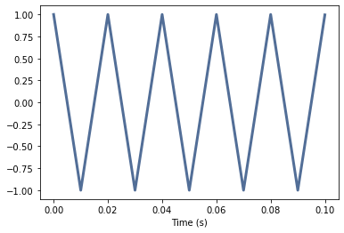

```python
in_wave = thinkdsp.TriangleSignal(freq=50).make_wave(duration=0.1, framerate=44100)
in_wave.plot()
thinkplot.config(xlabel='Time (s)')
in_wave.make_audio()
```

The diff of a triangle wave is a square wave, which explains why the harmonics in a square wave drop off like $1/f$, compared to the triangle wave, which drops off like $1/f^2$.

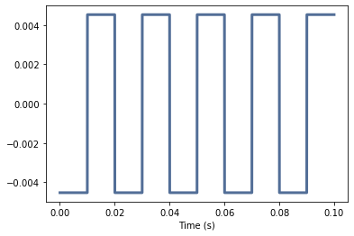

```python
out_wave = in_wave.diff()
out_wave.plot()
thinkplot.config(xlabel='Time (s)')
```

When we take the spectral derivative, we get "ringing" around the discontinuities: https://en.wikipedia.org/wiki/Ringing_(signal)

Mathematically speaking, the problem is that the derivative of the triangle wave is undefined at the points of the triangle.

[interactive chart not shown]

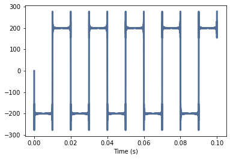

```python
out_wave2 = in_wave.make_spectrum().differentiate().make_wave()
out_wave2.plot()
thinkplot.config(xlabel='Time (s)')
out_wave2.make_audio()
```

[interactive chart not shown]

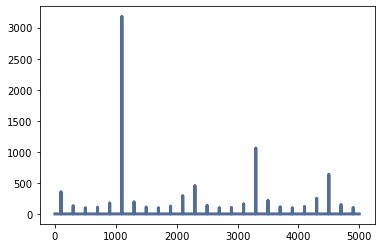

```python
square = thinkdsp.SquareSignal(1100).make_wave(duration=0.5, framerate=10000)
square.make_spectrum().plot()
square.make_audio()
```

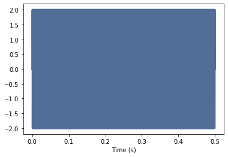

```python
out_wave1 = square.diff()
out_wave1.plot()
thinkplot.config(xlabel='Time (s)')
```

[interactive chart not shown]

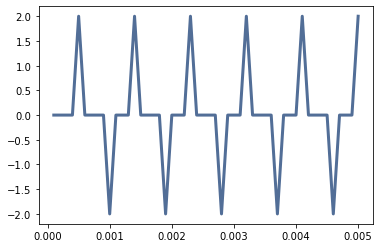

```python
segment1 = out_wave1.segment(duration=0.005)
segment1.plot()
segment1.make_audio()
```

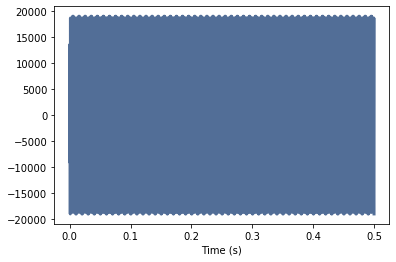

```python
out_wave3 = square.make_spectrum().differentiate().make_wave()
out_wave3.plot()
thinkplot.config(xlabel='Time (s)')
```

[interactive chart not shown]

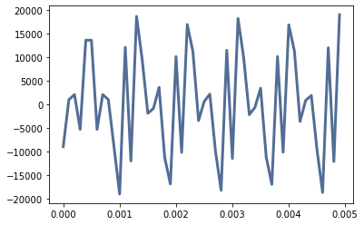

```python
segment3 = out_wave3.segment(duration=0.005)
segment3.plot()
segment3.make_audio()
```

```python
class SawtoothSignal(thinkdsp.Sinusoid):
    """Represents a sawtooth signal."""

    def evaluate(self, ts):
        """Evaluates the signal at the given times.

        ts: float array of times

        returns: float wave array
        """
        cycles = self.freq * ts + self.offset / PI2
        frac, _ = np.modf(cycles)
        ys = thinkdsp.normalize(thinkdsp.unbias(frac), self.amp)
        return ys
```

```python
sawtooth = SawtoothSignal().make_wave(duration=0.5, framerate=40000)
sawtooth.make_audio()
```

[interactive chart not shown]

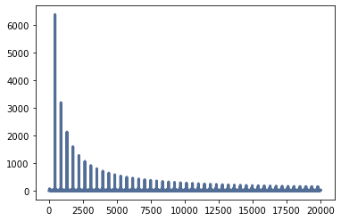

```python
sawtooth.make_spectrum().plot()
```

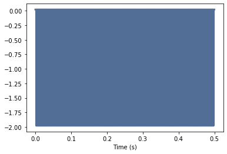

```python
out_wave4 = sawtooth.diff()
out_wave4.plot()
thinkplot.config(xlabel='Time (s)')
```

[interactive chart not shown]

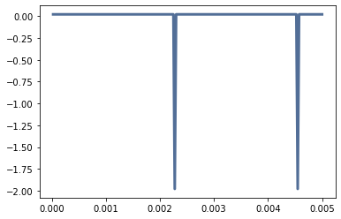

```python
segment4 = out_wave4.segment(duration=0.005)
segment4.plot()
segment4.make_audio()
```

```python
para = thinkdsp.ParabolicSignal(freq=500).make_wave(duration=0.5, framerate=20000)
para.make_audio()
```

[interactive chart not shown]

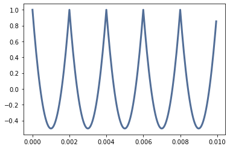

```python
para.segment(duration=0.01).plot()
```

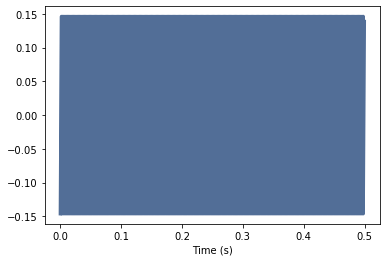

```python
out_wave5 = para.diff()
out_wave5.plot()
thinkplot.config(xlabel='Time (s)')
```

[interactive chart not shown]

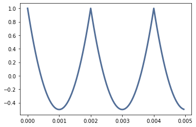

```python
segment5 = para.segment(duration=0.005)
segment5.plot()
segment5.make_audio()
```

[interactive chart not shown]

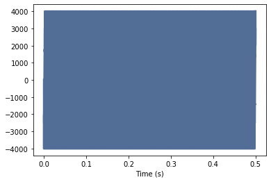

```python
out_wave22 = para.make_spectrum().differentiate().make_wave()
out_wave22.plot()
thinkplot.config(xlabel='Time (s)')
out_wave22.make_audio()
```

[interactive chart not shown]

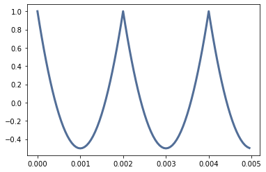

```python
segment55 = para.segment(duration=0.005)
segment55.plot()
segment55.make_audio()
```